# Bootstrapping a fitted model

Author

Phillip Alday, Douglas Bates, and Reinhold Kliegl

Published

2025-05-13

Begin by loading the packages to be used.

```julia
using AlgebraOfGraphics
using CairoMakie
using DataFrames
using MixedModels
using Random
using SMLP2025: dataset

const progress=false
```

# 1 Data set and model

The `kb07` data (Kronmüller & Barr, 2007) are one of the datasets provided by the `MixedModels` package.

```julia
kb07 = dataset(:kb07)
```

```
Arrow.Table with 1789 rows, 7 columns, and schema:
 :subj      String
 :item      String
 :spkr      String
 :prec      String
 :load      String
 :rt_trunc  Int16
 :rt_raw    Int16
```

Convert the table to a DataFrame for summary.

```julia
describe(DataFrame(kb07))
```

7×7 DataFrame

| Row | variable Symbol | mean Union… | min Any | median Union… | max Any | nmissing Int64 | eltype DataType |
| --- | --- | --- | --- | --- | --- | --- | --- |
| 1 | subj |  | S030 |  | S103 | 0 | String |
| 2 | item |  | I01 |  | I32 | 0 | String |
| 3 | spkr |  | new |  | old | 0 | String |
| 4 | prec |  | break |  | maintain | 0 | String |
| 5 | load |  | no |  | yes | 0 | String |
| 6 | rt_trunc | 2182.2 | 579 | 1940.0 | 5171 | 0 | Int16 |
| 7 | rt_raw | 2226.24 | 579 | 1940.0 | 15923 | 0 | Int16 |

The experimental factors; `spkr`, `prec`, and `load`, are two-level factors. The `EffectsCoding` contrast is used with these to create a $\pm1$ encoding.

```julia
contrasts = Dict{Symbol,Any}(nm => EffectsCoding() for nm in (:spkr, :prec, :load))
```

The display of an initial model fit

```julia
kbm01 = let
  form = @formula(
    rt_trunc ~
      1 +
      spkr * prec * load +
      (1 + spkr + prec + load | subj) +
      (1 + spkr + prec + load | item)
  )
  fit(MixedModel, form, kb07; contrasts, progress)
end
```

|  | Est. | SE | z | p | σ_subj | σ_item |
| --- | --- | --- | --- | --- | --- | --- |
| (Intercept) | 2181.6729 | 77.3131 | 28.22 | <1e-99 | 301.6736 | 362.3182 |
| spkr: old | 67.7490 | 18.2747 | 3.71 | 0.0002 | 42.5441 | 40.7073 |
| prec: maintain | -333.9206 | 47.1388 | -7.08 | <1e-11 | 61.9978 | 246.8078 |
| load: yes | 78.7702 | 19.5387 | 4.03 | <1e-04 | 64.9874 | 42.5139 |
| spkr: old & prec: maintain | -21.9655 | 15.8070 | -1.39 | 0.1646 |  |  |
| spkr: old & load: yes | 18.3838 | 15.8070 | 1.16 | 0.2448 |  |  |
| prec: maintain & load: yes | 4.5333 | 15.8070 | 0.29 | 0.7743 |  |  |
| spkr: old & prec: maintain & load: yes | 23.6072 | 15.8070 | 1.49 | 0.1353 |  |  |
| Residual | 668.5371 |  |  |  |  |  |

does not include the estimated correlations of the random effects.

The `VarCorr` extractor displays these.

```julia
VarCorr(kbm01)
```

|  | Column | Variance | Std.Dev | Corr. |  |  |
| --- | --- | --- | --- | --- | --- | --- |
| subj | (Intercept) | 91006.9887 | 301.6736 |  |  |  |
|  | spkr: old | 1810.0012 | 42.5441 | +0.79 |  |  |
|  | prec: maintain | 3843.7268 | 61.9978 | -0.59 | +0.02 |  |
|  | load: yes | 4223.3647 | 64.9874 | +0.36 | +0.85 | +0.54 |
| item | (Intercept) | 131274.4558 | 362.3182 |  |  |  |
|  | spkr: old | 1657.0830 | 40.7073 | +0.44 |  |  |
|  | prec: maintain | 60914.1141 | 246.8078 | -0.69 | +0.35 |  |
|  | load: yes | 1807.4303 | 42.5139 | +0.32 | +0.15 | -0.14 |
| Residual |  | 446941.7901 | 668.5371 |  |  |  |

None of the two-factor or three-factor interaction terms in the fixed-effects are significant. In the random-effects terms only the scalar random effects and the `prec` random effect for `item` appear to be warranted, leading to the reduced formula

```julia
kbm02 = let
  form = @formula(
    rt_trunc ~
      1 + spkr + prec + load + (1 | subj) + (1 + prec | item)
  )
  fit(MixedModel, form, kb07; contrasts, progress)
end
```

|  | Est. | SE | z | p | σ_item | σ_subj |
| --- | --- | --- | --- | --- | --- | --- |
| (Intercept) | 2181.8526 | 77.4681 | 28.16 | <1e-99 | 364.7125 | 298.0259 |
| spkr: old | 67.8790 | 16.0785 | 4.22 | <1e-04 |  |  |
| prec: maintain | -333.7906 | 47.4472 | -7.03 | <1e-11 | 252.5212 |  |
| load: yes | 78.5904 | 16.0785 | 4.89 | <1e-05 |  |  |
| Residual | 680.0319 |  |  |  |  |  |

```julia
VarCorr(kbm02)
```

|  | Column | Variance | Std.Dev | Corr. |
| --- | --- | --- | --- | --- |
| item | (Intercept) | 133015.242 | 364.713 |  |
|  | prec: maintain | 63766.937 | 252.521 | -0.70 |
| subj | (Intercept) | 88819.438 | 298.026 |  |
| Residual |  | 462443.388 | 680.032 |  |

These two models are nested and can be compared with a likelihood-ratio test.

```julia
MixedModels.likelihoodratiotest(kbm02, kbm01)
```

|  | model-dof | deviance | χ² | χ²-dof | P(>χ²) |
| --- | --- | --- | --- | --- | --- |
| rt_trunc ~ 1 + spkr + prec + load + (1 \| subj) + (1 + prec \| item) | 9 | 28664 |  |  |  |
| rt_trunc ~ 1 + spkr + prec + load + spkr & prec + spkr & load + prec & load + spkr & prec & load + (1 + spkr + prec + load \| subj) + (1 + spkr + prec + load \| item) | 29 | 28637 | 27 | 20 | 0.1431 |

# 2 A bootstrap sample

Create a bootstrap sample of a few thousand parameter estimates from the reduced model. The pseudo-random number generator is initialized to a fixed value for reproducibility.

```julia
Random.seed!(1234321)
kbm02samp = parametricbootstrap(2000, kbm02)
kbm02tbl = kbm02samp.tbl
```

```
Table with 14 columns and 2000 rows:
      obj      β1       β2       β3        β4       σ        σ1       σ2       ⋯
    ┌───────────────────────────────────────────────────────────────────────────
 1  │ 28772.3  2163.91  60.5609  -312.083  53.8854  702.338  372.786  244.827  ⋯
 2  │ 28715.1  2232.6   83.7997  -383.283  47.4501  693.167  391.838  214.007  ⋯
 3  │ 28575.3  2194.67  65.0581  -348.837  78.2132  660.998  380.111  241.468  ⋯
 4  │ 28728.5  2261.27  66.174   -351.407  89.6083  690.344  334.599  306.404  ⋯
 5  │ 28631.4  2309.15  77.5687  -341.306  72.5969  676.497  323.766  269.468  ⋯
 6  │ 28627.8  2091.9   54.8119  -295.505  74.487   667.146  426.8    278.072  ⋯
 7  │ 28685.7  2291.62  73.7219  -396.564  84.4817  687.627  393.806  194.632  ⋯
 8  │ 28654.4  2019.04  72.7075  -203.806  87.8736  679.826  304.365  208.355  ⋯
 9  │ 28664.1  1999.72  60.8485  -308.63   74.0233  680.412  357.133  305.422  ⋯
 10 │ 28618.3  2249.85  52.1815  -394.464  89.8091  670.656  385.063  226.332  ⋯
 11 │ 28748.9  2166.95  77.9659  -326.597  81.0316  696.842  378.964  234.475  ⋯
 12 │ 28731.4  2153.68  74.5144  -341.393  44.1758  701.902  323.245  177.602  ⋯
 13 │ 28623.9  2155.23  93.193   -373.267  73.2941  671.256  335.979  217.312  ⋯
 14 │ 28615.9  2344.1   62.8553  -314.684  88.7448  665.313  410.652  259.437  ⋯
 15 │ 28636.2  2286.5   35.9889  -349.732  62.0524  670.473  361.649  304.037  ⋯
 16 │ 28676.6  2289.43  76.9805  -298.765  87.139   686.466  316.203  232.853  ⋯
 17 │ 28614.8  2044.53  53.2336  -304.859  112.995  675.065  354.352  220.038  ⋯
 ⋮  │    ⋮        ⋮        ⋮        ⋮         ⋮        ⋮        ⋮        ⋮     ⋱
```

One of the uses of such a sample is to form “confidence intervals” on the parameters by obtaining the shortest interval that covers a given proportion (95%, by default) of the sample.

```julia
confint(kbm02samp)
```

```
DictTable with 2 columns and 9 rows:
 par   lower      upper
 ────┬─────────────────────
 β1  │ 2022.91    2334.0
 β2  │ 34.0592    96.72
 β3  │ -430.238   -239.803
 β4  │ 46.5349    109.526
 ρ1  │ -0.907256  -0.490089
 σ   │ 657.341    702.655
 σ1  │ 270.067    451.968
 σ2  │ 181.737    325.124
 σ3  │ 233.834    364.512
```

A sample like this can be used for more than just creating an interval because it approximates the distribution of the estimator. For the fixed-effects parameters the estimators are close to being normally distributed, Figure 1.

[output not shown]

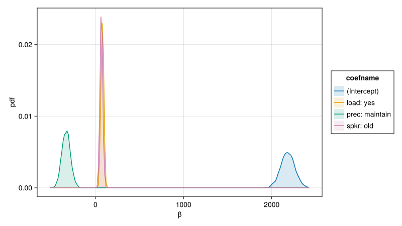

Figure 1: Comparative densities of the fixed-effects coefficients in kbm02samp

```julia
draw(
  data(kbm02samp.β) * mapping(:β; color=:coefname) * AlgebraOfGraphics.density();
  figure=(; resolution=(800, 450)),
)
```

[output not shown]

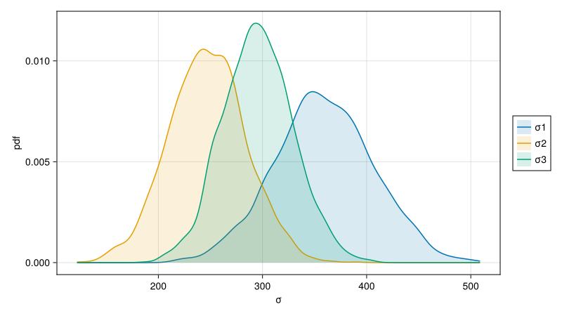

Figure 2: Density plot of bootstrap samples standard deviation of random effects

```julia
let pars = ["σ1", "σ2", "σ3"]
  draw(
    data(kbm02tbl) *
    mapping(pars .=> "σ"; color=dims(1) => renamer(pars)) *
    AlgebraOfGraphics.density();
    figure=(; resolution=(800, 450)),
  )
end
```

[output not shown]

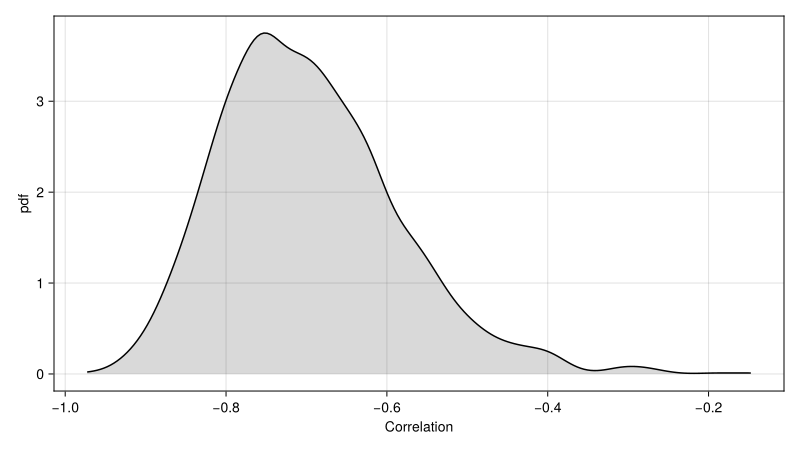

Figure 3: Density plot of correlation parameters in bootstrap sample from model kbm02

```julia
draw(
  data(kbm02tbl) *
  mapping(:ρ1 => "Correlation") *
  AlgebraOfGraphics.density();
  figure=(; resolution=(800, 450)),
)
```

# 3 References

Kronmüller, E., & Barr, D. J. (2007). Perspective-free pragmatics: Broken precedents and the recovery-from-preemption hypothesis. *Journal of Memory and Language*, *56*(3), 436–455. https://doi.org/10.1016/j.jml.2006.05.002

*This page was rendered from git revision [1a894e8](https://github.com/RePsychLing/SMLP2025/tree/1a894e8  
) using Quarto 1.7.29.*

Back to top